# Distribution Free Methods: Introduction

## Distribution Free Methods

Distribution free methods do not assume the data are drawn from any specific probability distribution. *Important: distribution-free, not assumption-free (e.g., IID).*

- Randomization
  - Shuffle data set in some way
- Resampling
  - Sample from data set in some way
    - Jackknife
    - Bootstrap

## Why distribution free methods?

- Real data often does not follow standard distributions
- Very flexible
- Uses only information from your data set
  - Good & Bad
- Standard errors can not always be calculated for all parameters

## Resampling

- Primarily a method for parameter estimation and interval estimation
- Sample from the data to estimate the variability in the parameter estimate
- **Assumption:** Observed distribution is representative of the true distribution
- Need to empirically show the method works for each type of application using simulation

## Randomization

- Primarily a method for hypothesis testing
- More directly asks: What is the probability of observing a result as extreme or more than my observed result?

**Assumption:** Under the null hypothesis, observations are random draws from a common population

## Hypothesis testing by randomization

[figure not shown]

## Hypothesis testing by randomization

Mandible lengths of female and male jackals from the Natural History Museum (London).

```r
M <- read_excel("../data/Jackals.xlsx")
glimpse(M)
```

```
## Rows: 20
## Columns: 2
## $ Mandible <dbl> 110, 111, 107, 108, 110, 105, 107, 106, 111, 111, 120, 107, 1…
## $ Sex      <chr> "F", "F", "F", "F", "F", "F", "F", "F", "F", "F", "M", "M", "…
```

```r
M <- M %>% mutate(Sex = factor(Sex)) %>% as.data.frame()
```

## Randomization tests

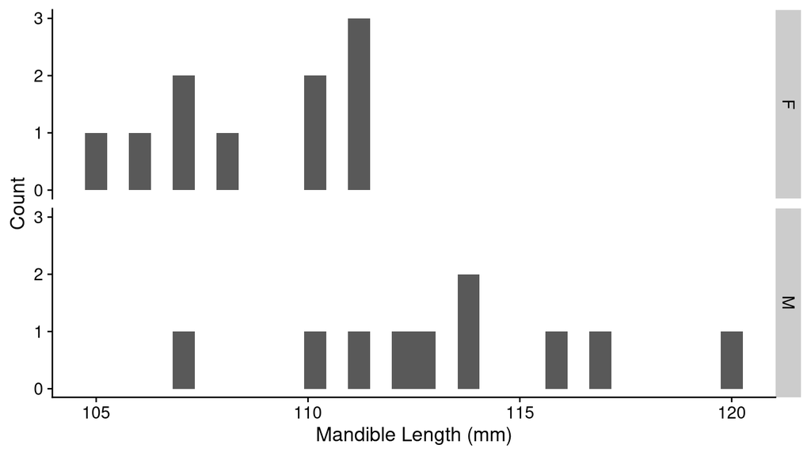

## Randomization tests

We’d like to do a *t*-test to compare group means.

But:

1. Assumes random sampling
2. Assumes equal group variances
3. Assumes normal distribution within groups

## Randomization procedure

1. Decide on a test statistic
2. Calculate the test statistic for the *observed* data
3. Randomly shuffle the observations
4. Calculate the test statistic for that group
5. Repeat thousands of times
6. Determine the proportion of random combinations resulting in a test statistic more extreme than the observed value (“empirical *P*”)

When test assumptions are met, the results will match asymptotic procedures. When the assumptions are not met, the results will be valid.

## Decide on a test statistic

1. Mean difference
2. *t*: *t*-test, linear model parameter estimate (slope, intercept)
3. *F*: ANOVA-like
4. \(\chi^2\)
5. Any metric of your choice (P-value, Fst, heterozygosity, LOD score, etc.)

## Calculate the test statistic for the observed data

Observed difference in mean value for females vs. males:

```r
(obs <- mean(M$Mandible[M$Sex == "F"]) -
   mean(M$Mandible[M$Sex == "M"]))
```

```
## [1] -4.8
```

## Randomly reassign, recalculate, repeat

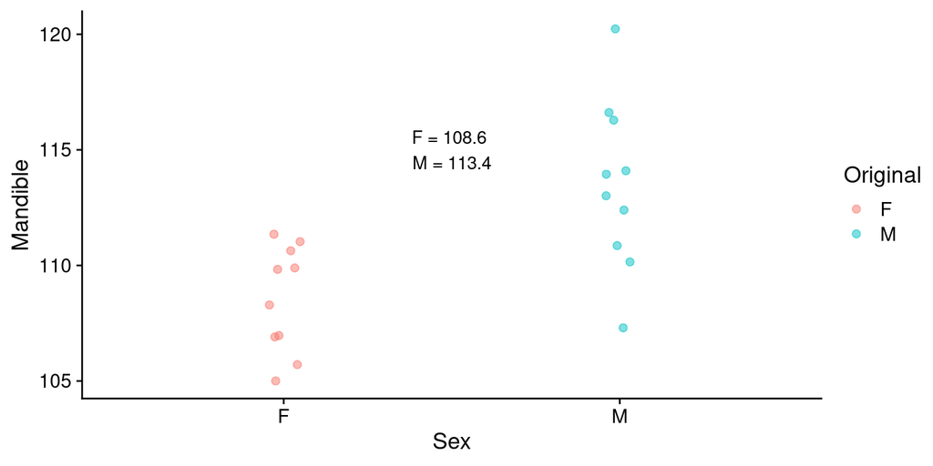

## Randomly reassign, recalculate, repeat

Shuffle Sex

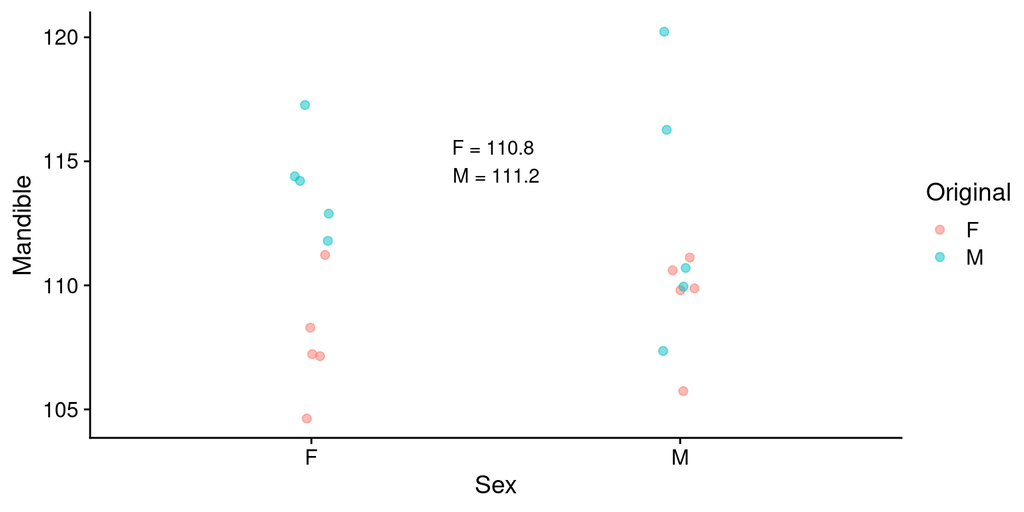

## Randomly reassign, recalculate, repeat

Repeat N times

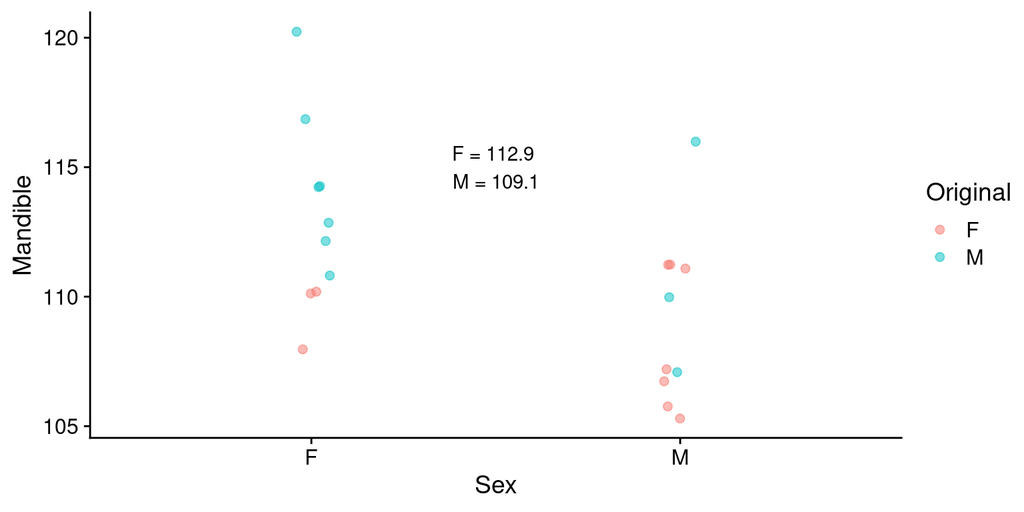

## Randomly reassign, recalculate, repeat

```r
# Set random number seed
set.seed(10)

nreps <- 1e4
diffs <- numeric(length = nreps)
diffs[1] <- obs
for (ii in 2:nreps) {
  Rand_Sex <- sample(M$Sex)
  diffs[ii] <- mean(M$Mandible[Rand_Sex == "F"]) -
    mean(M$Mandible[Rand_Sex == "M"])
}
```

## Visualize the results

```r
ggplot(data.frame(diffs), aes(diffs)) +
  geom_histogram(bins = 25) +
  geom_vline(xintercept = diffs[1], color = "red") +
  labs(x = "Difference", y = "Count")
```

Histogram of the randomized differences, vertical red line to mark the observed value.

## Visualize the results

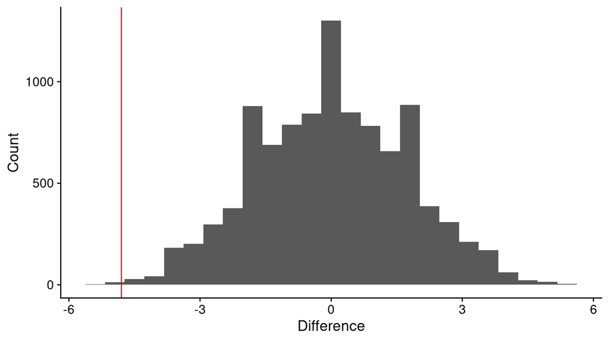

## Proportion of randomized differences more extreme than the observed

```r
mean(diffs <= diffs[1])
```

```
## [1] 0.0016
```

Mean of `diffs` where the value is *less than or equal to* the observed mean difference.

Empirically determined *P*-value is 0.0016.

## Example: Age predicted by coloration in lion noses

[figure not shown]

## Age predicted by coloration in lion noses

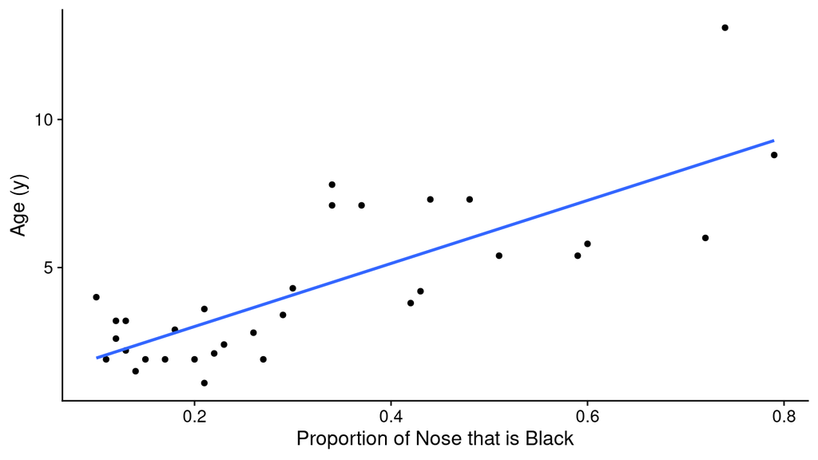

## Age predicted by nose coloration

```r
fm <- lm(age ~ proportion.black, data = LionNoses)
summary(fm)
```

```
##
## Call:
## lm(formula = age ~ proportion.black, data = LionNoses)
##
## Residuals:
##     Min      1Q  Median      3Q     Max
## -2.5449 -1.1117 -0.5285  0.9635  4.3421
##
## Coefficients:
##                  Estimate Std. Error t value Pr(>|t|)
## (Intercept)        0.8790     0.5688   1.545    0.133
## proportion.black  10.6471     1.5095   7.053 7.68e-08 ***
## ---
## Signif. codes:  0 '***' 0.001 '**' 0.01 '*' 0.05 '.' 0.1 ' ' 1
##
## Residual standard error: 1.669 on 30 degrees of freedom
## Multiple R-squared:  0.6238, Adjusted R-squared:  0.6113
## F-statistic: 49.75 on 1 and 30 DF,  p-value: 7.677e-08
```

## Age predicted by nose coloration

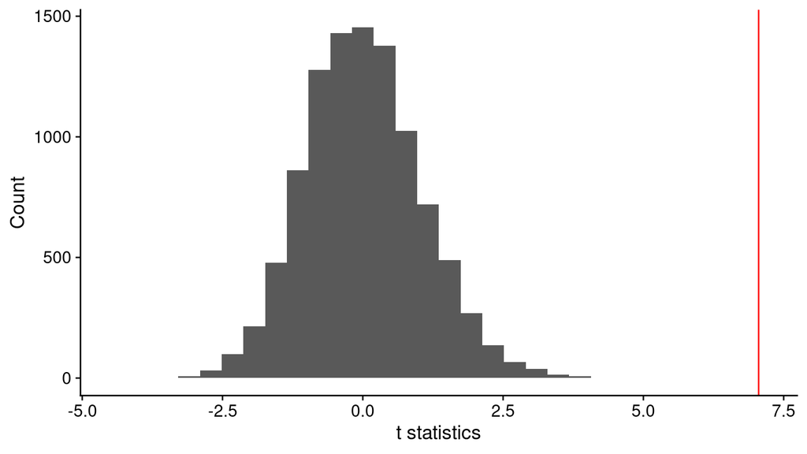

## Age predicted by nose coloration

```r
2 * mean(t_stats >= t_stats[1])
```

```
## [1] 2e-04
```

Note sign of the inequality: how often does the randomized age data give a *larger* *t* statistic than the observed?

Why 2 x 10<sup>-4</sup>?

## Empirical *P* vs. Iterations

What is the minimal detectable *P* for *n* iterations?

|  | nreps | min_P |
| --- | --- | --- |
| 2 | 18 | 0.1111111 |
| 4 | 63 | 0.0317460 |
| 6 | 219 | 0.0091324 |
| 8 | 756 | 0.0026455 |
| 10 | 2604 | 0.0007680 |
| 12 | 8966 | 0.0002231 |
| 14 | 30865 | 0.0000648 |
| 16 | 106246 | 0.0000188 |
| 18 | 365727 | 0.0000055 |
| 20 | 1258925 | 0.0000016 |

## Non-parametric tests

Non-parametric tests often used when data do not meet the assumptions of a traditional (parametric) test:

- One-sample *t*-test \(\rightarrow\) Sign test, Wilcoxon test
- Two-sample *t*-test \(\rightarrow\) Mann-Whitney test
- ANOVA \(\rightarrow\) Kruskal-Wallis

Small sample size, non-normality, unequal variances

**Dramatically lower power compared to a parametric test**

## Randomization as an alternative

For all practical cases, randomization is a better alternative

- Increased power
- No reliance on asymptotic properties of tests
- More relaxed assumptions